# Univariate state-space models

## Log-population size over time

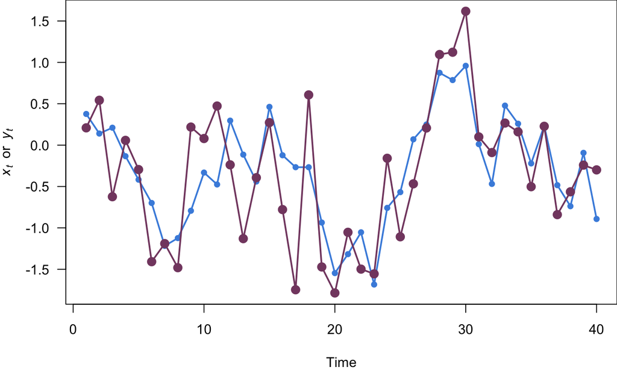

## Fitting models

## Fitting models with `MARSS()`

Recall that `MARSS()` uses an expanded form of state-space model, such that

\[ \begin{align} x_t &= b x_{t-1} + w_t \\ y_t &= x_t + v_t \\ & \Downarrow \\ x_t &= b x_{t-1} + u + w_t \\ y_t &= Z x_t + a + v_t \end{align} \]

with \(u = 0\), \(Z = 1\), and \(a = 0\)

## Fitting models with `MARSS()`

State model  
\(x_t = b x_{t-1} + u + w_t ~~ \text{with} ~~ w_t \sim \text{N}(0,q)\)

Observation model  
\(y_t = Z x_t + a + v_t ~~ \text{with} ~~ v_t \sim \text{N}(0,r)\)

```r
mod_list <- list(
  ## state model
  B = matrix("b"), U = matrix(0), Q = matrix("q"),
  ## obs model
  Z = matrix(1), A = matrix(0), R = matrix("r")
  )
```

**Note**: `MARSS()` works with the `matrix` class in **R**, so we have to define any scalar as a \(1 \times 1\) matrix

## Fitting models with `MARSS()`

We can ignore the `inits` and `control` arguments for now and fit the model

```r
## define the data as an N (rows) x T (cols) matrix
dat <- matrix(yy, nrow = 1, ncol = TT)
## fit the model
mod_fit <- MARSS(y = dat, model = mod_list)
```

## Fitting models with `MARSS()`

```
## Success! abstol and log-log tests passed at 19 iterations.
## Alert: conv.test.slope.tol is 0.5.
## Test with smaller values (<0.1) to ensure convergence.
##
## MARSS fit is
## Estimation method: kem
## Convergence test: conv.test.slope.tol = 0.5, abstol = 0.001
## Estimation converged in 19 iterations.
## Log-likelihood: -45.16756
## AIC: 98.33512   AICc: 99.47797
##
##       Estimate
## R.r      0.277
## B.b      0.784
## Q.q      0.199
## x0.x0    0.268
## Initial states (x0) defined at t=0
##
## Standard errors have not been calculated.
## Use MARSSparamCIs to compute CIs and bias estimates.
```

## Covariates in state-space models

## Covariates in state-space models

We can include covariates (explanatory variables) as well

Covariates in the state model *affect the underlying process*

\[ x_t = b x_{t-1} + C c_t + w_t \]

## Covariates in state-space models

We can include covariates (explanatory variables) as well

Covariates in the state model *affect the underlying process*

\[ x_t = b x_{t-1} + C c_t + w_t \]

Covariates in the observation model are *offsets to the underlying process*

\[ y_t = Z x_t + D d_t + v_t \]

## Covariates in state-space models

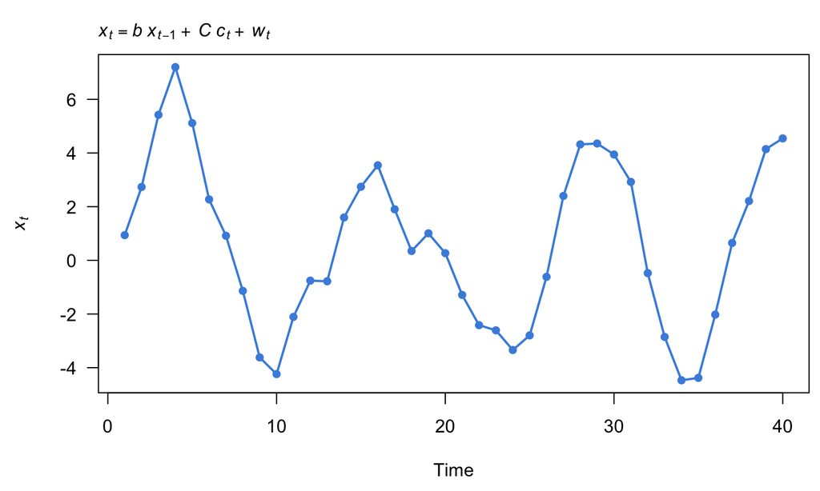